# Outlet

The Outlet lets water flow downstream with a prescribed flow rate. It is similar to the Pump, except that water only flows down, by gravity.

When PID controlled, the Outlet must point towards the controlled Basin in terms of links.

# 1 Schematic

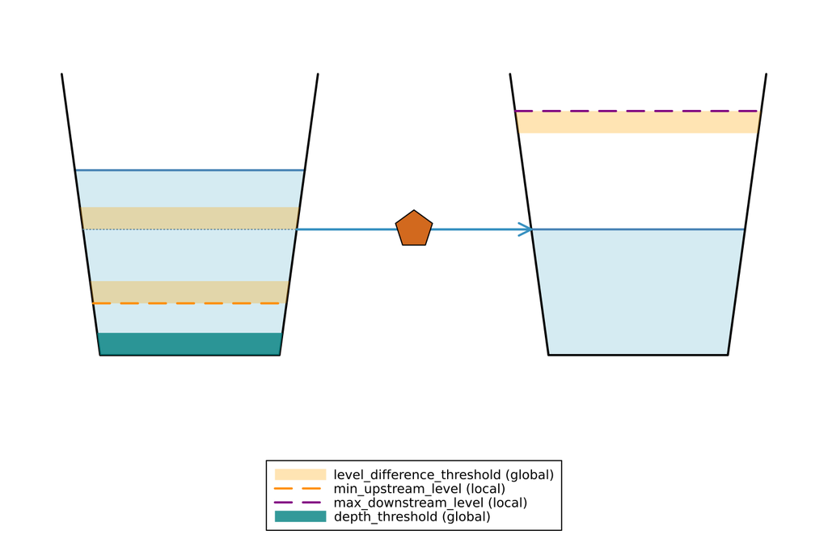

```julia
include("../../../utils/plot_connector_schematic.jl")
plot_connector_schematic(:Outlet)
```

# 2 Allowed connectivity

```julia
include("../../../utils/plot_node_connectivity.jl")
plot_node_connectivity("Outlet")
```

[figure not shown]

# 3 Tables

## 3.1 Static

```julia
include("../../../utils/gen_docs_table.jl")
const OUTLET_RESTRICTIONS = Dict(:flow_rate => "non-negative")
table_from_schema(Ribasim.Schema.Outlet.Static; restrictions = OUTLET_RESTRICTIONS)
```

| column | type | unit | optional | default | restriction |
| --- | --- | --- | --- | --- | --- |
| node_id | Int32 | - | x | - | - |
| flow_rate | Float64 | m³ s⁻¹ | x | - | non-negative |
| min_flow_rate | Float64 | m³ s⁻¹ | ✓ | 0.0 | - |
| max_flow_rate | Float64 | m³ s⁻¹ | ✓ | Inf | - |
| min_upstream_level | Float64 | m | ✓ | -Inf | - |
| max_downstream_level | Float64 | m | ✓ | Inf | - |
| control_state | String | - | ✓ | - | - |
| allocation_controlled | Bool | - | ✓ | false | - |

## 3.2 Time

This table is the transient form of the `Outlet` table. With this all parameters can be updated over time. In between the given times the values are block interpolated (forward fill), and outside the values are constant given by the nearest time value. Note that a `node_id` can be either in this table or in the static one, but not both.

```julia
table_from_schema(Ribasim.Schema.Outlet.Time; restrictions = OUTLET_RESTRICTIONS)
```

| column | type | unit | optional | default | restriction |
| --- | --- | --- | --- | --- | --- |
| node_id | Int32 | - | x | - | - |
| time | DateTime | - | x | - | - |
| flow_rate | Float64 | m³ s⁻¹ | x | - | non-negative |
| min_flow_rate | Float64 | m³ s⁻¹ | ✓ | 0.0 | - |
| max_flow_rate | Float64 | m³ s⁻¹ | ✓ | Inf | - |
| min_upstream_level | Float64 | m | ✓ | -Inf | - |
| max_downstream_level | Float64 | m | ✓ | Inf | - |

# 4 Equations

The Outlet is very similar to the Pump, but it has an extra reduction factor for physical constraints:

$$Q = \phi_\text{level} \, \mathrm{clamp}(\phi_\text{storage} Q_\text{set}, Q_{\min}, Q_{\max})$$

- $Q$ is the actual Outlet flow rate.
- $Q_\text{set}$ is the Outlet’s target `flow_rate`.
- $Q_{\min}$ and $Q_{\max}$ are the Outlet `min_flow_rate` and `max_flow_rate`.
- $\phi_\text{storage}$ is the reduction factor that smoothly reduces flow when the upstream volume is below the equivalent of a water depth of `depth_threshold`.
- $\phi_\text{level}$ is the product of the reduction factors that smoothly reduce flow based on these criteria:
  - The upstream level goes from `downstream_level` + `level_difference_threshold` to `downstream_level`.
  - The upstream level goes from `min_upstream_level` + `level_difference_threshold` to `min_upstream_level`.
  - The downstream level goes from `max_downstream_level` - `level_difference_threshold` to `max_downstream_level`.

For `depth_threshold`, `level_difference_threshold` see Solver settings.

Since $\phi_\text{level}$ is applied after the clamp, `min_flow_rate` is not a strict minimum: the level criteria can still reduce the flow to zero.